# Video Games Market for the period 1980 - 2016

### Video Games Market for the period 1980 - 2016

Author: Alexander Feldman

1. Open the data file.
2. Preprocessing.
3. Exploratory data analysis (EDA).
4. Creating a user profile for each region.
5. Testing the hypotheses.
6. Conclusions and recommendations.

## 1. Opening the data file

```python
#!pip install pandas_profiling
```

```python
# import
import pandas as pd
import numpy as np
import math as mt
from scipy import stats as st
from matplotlib import pyplot as plt
import seaborn as sns
import squarify
import pandas_profiling as pp
pd.set_option('display.max_columns', 500)
```

```python
# open file
try:
    df = pd.read_csv('datasets/games.csv')
except:
    df = pd.read_csv('/datasets/games.csv')
```

```python
# Study the general information by ProfileReport
#pp.ProfileReport(df)
```

I studied general information about dataframe. The quality of data is good. Dataframe has 16715 rows. There are 12,1% missing values. There are no duplicate values. The column Name has two missing values (<0,1%). The column Year of release has 269 missing values (1,6%). The column Genre has 2 missing values (<0,1%). The column Critic_score has 8578 missing values (51.3%). The column User_Score has 6701 missing values (40.1%) and has and has both numeric and string values ('tbd' - 2424 values). The column Rating has 6766 missing values (40.5%).

## 2. Preprocessing

```python
# convert text to lowercase for label of columns and string variables
df.columns = df.columns.str.lower()
df['name'] = df['name'].str.lower()
df['platform'] = df['platform'].str.lower()
df['genre'] = df['genre'].str.lower()
df['rating'] = df['rating'].str.lower()
```

```python
# Study missing values in Name column. It has 2 missing values
df[df['name'].isna()]
```

|  | name | platform | year_of_release | genre | na_sales | eu_sales | jp_sales | other_sales | critic_score | user_score | rating |
| --- | --- | --- | --- | --- | --- | --- | --- | --- | --- | --- | --- |
| 659 | NaN | gen | 1993.0 | NaN | 1.78 | 0.53 | 0.00 | 0.08 | NaN | NaN | NaN |
| 14244 | NaN | gen | 1993.0 | NaN | 0.00 | 0.00 | 0.03 | 0.00 | NaN | NaN | NaN |

```python
# First row has not small values of sales. Restore one.

# replace missing values in Name with fake names
df.loc[659, 'name'] = 'Unknow game'
# also add most popular genre for one
df.loc[659, 'genre'] = 'action'

# Drop second row
df.dropna(subset=['name'], inplace=True)
```

```python
# Study of year_of_release column. It has 269 missing value
# Restore missing values by function.

def year_from_name(row):

    '''
    The function restore missing values in year_of_release column.

    '''
    game = row[0]
    plat = row[1]
    year = row[2]


    if pd.isna(year) == True:

        # step 1. attempt to restore value by value of the same game on other platforms
        df_game = df[df['name'].str.contains(game)]
        year_game = df_game['year_of_release'].mean()
        if pd.notna(year_game) == True:
            return year_game

        # step 2. attempt to restore value by extract year from name of game
        for y in range(1980, 2017): # pattern 19xx, 20xx
            y = str(y)
            if y in game:
                return y

        for x in range(80, 99+1): # pattern 99, ...
            x = str(x)
            if x in game:
                return '19'+x

        for z in range(0, 10): # pattern 05, 07, ...
            z = '0'+str(z)
            if z in game:
                return '20'+z

        for q in range(11, 17): # pattern 10, 11, ...
            q = str(q)
            if q in game:
                return '20'+q

        for s in range(1, 10): # pattern 2k6, ...
            s=str(s)
            s1 = '2k'+s
            if s1 in game:
                return '200'+s

        # step 3. attempt to restore value by value of the game
        # with the same first word in the name
        game_cut = game.split(' ', 1)[0]
        df_game = df[df['name'].str.contains(game_cut)]
        year_game = df_game['year_of_release'].mean()
        if pd.notna(year_game) == True:
            return year_game

        # step 4. remaining names restore by mean year of platform
        df_game = df[df['platform'] == plat]
        year_game = df_game['year_of_release'].mean()
        if pd.notna(year_game) == True:
            return year_game

    else:
        return year

df['year_of_release'] = df.apply(year_from_name, axis=1).astype('int')
# missing values in year_of_release have restored
```

```python
# I decided to fill missing values by 0 for score columns because it's more suitable for processing.
# But for analysis, I will use values without null-values.

df['critic_score'] = df['critic_score'].fillna(0)
df['user_score'] = df['user_score'].fillna(0)
# Replace 'tbd' with 0 in user_score and convert type of value
df['user_score'] = df['user_score'].replace('tbd', 0).astype('float')
```

```python
# Restore missing values for Rating column

df['rating'] = df['rating'].fillna('no rating')
df['rating'] = df['rating'].replace('k-a', 'e') # because K-A rating was changed to E rating in 1998.
df['rating'] = df['rating'].replace('rp', 'no rating') # because RP rating it's really no rating
```

```python
# Make total_sales column
df['total_sales'] = df[['na_sales', 'eu_sales', 'jp_sales', 'other_sales']].sum(axis=1)
```

```python
# the dataset is ready
df.sample(10)
```

|  | name | platform | year_of_release | genre | na_sales | eu_sales | jp_sales | other_sales | critic_score | user_score | rating | total_sales |
| --- | --- | --- | --- | --- | --- | --- | --- | --- | --- | --- | --- | --- |
| 11971 | escape dead island | x360 | 2014 | action | 0.03 | 0.04 | 0.00 | 0.01 | 32.0 | 3.8 | m | 0.08 |
| 9120 | pro evolution soccer 2015 | xone | 2014 | sports | 0.03 | 0.10 | 0.00 | 0.01 | 79.0 | 7.3 | e | 0.14 |
| 1719 | gun | ps2 | 2005 | shooter | 0.98 | 0.04 | 0.00 | 0.16 | 77.0 | 8.7 | m | 1.18 |
| 3309 | tomb raider (2013) | xone | 2014 | action | 0.35 | 0.21 | 0.00 | 0.05 | 0.0 | 0.0 | no rating | 0.61 |
| 9530 | puyo puyo!! 20th anniversary | 3ds | 2011 | puzzle | 0.00 | 0.00 | 0.13 | 0.00 | 0.0 | 0.0 | no rating | 0.13 |
| 6844 | front line | 2600 | 1981 | action | 0.22 | 0.01 | 0.00 | 0.00 | 0.0 | 0.0 | no rating | 0.23 |
| 6790 | guitar freaks | ps | 1999 | simulation | 0.00 | 0.00 | 0.23 | 0.02 | 0.0 | 0.0 | no rating | 0.25 |
| 13544 | heatseeker | psp | 2007 | action | 0.04 | 0.00 | 0.00 | 0.00 | 49.0 | 0.0 | t | 0.04 |
| 7992 | .hack//quarantine part 4: the final chapter | ps2 | 2003 | role-playing | 0.09 | 0.07 | 0.00 | 0.02 | 0.0 | 0.0 | no rating | 0.18 |
| 14916 | cid the dummy | wii | 2009 | platform | 0.02 | 0.00 | 0.00 | 0.00 | 31.0 | 0.0 | e10+ | 0.02 |

I have prepared data for analysis. I have restored missing values and converted format data to appropriate forms.

## 3. Exploratory data analysis (EDA)

```python
# Explore how many games were released in different years.
# Since one game is released on one or some platforms,
# we can split the entities: first release of the game on some
# platform and release of the game on all platforms.

name_first_release=df.pivot_table(index='name', values='year_of_release',
                                  aggfunc='min').reset_index() # get info about first releses
num_release_by_years = df.pivot_table(index='year_of_release', values='name',
                                      aggfunc=['count']) # get info about all releases
num_release_by_years.columns=['Release on all platform']
num_release_by_years['First release'] = (
    name_first_release.groupby(['year_of_release'])['name'].count()) # join ones
```

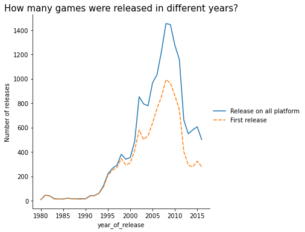

```python
# build plot
sns.relplot(data=num_release_by_years, kind='line')
plt.title('How many games were released in different years?', fontdict={'size':15})
plt.ylabel('Number of releases')
plt.show()
```

```python
# What is the most profitable platform?
df.groupby('platform')['total_sales'].sum().idxmax()
```

```
'ps2'
```

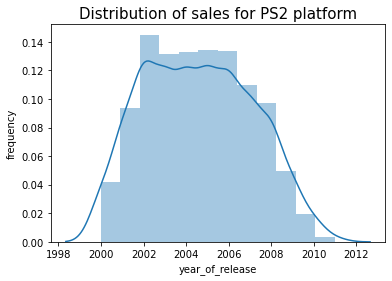

```python
# PS2 was the most profitable platform. Let's see distribution of sales for PS2.
ps2_plot = df[df['platform'] == 'ps2']['year_of_release']
sns.distplot(ps2_plot, bins=12)
plt.title('Distribution of sales for PS2 platform', fontdict={'size':15})
plt.ylabel('frequency')
plt.show()
```

```python
# time of life ps2 was about 12 years.
# how long time lives other platforms?
ordered = df.pivot_table(index='platform', values='year_of_release', aggfunc=['min', 'max'])
ordered.columns=['year_of_brth', 'year_of_death']
ordered['years_of_life'] = ordered['year_of_death'] - ordered['year_of_brth']
ordered = ordered.sort_values('years_of_life', ascending=False).reset_index()
```

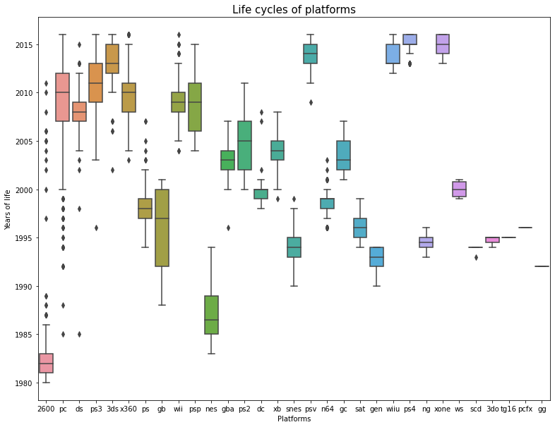

```python
plt.figure(figsize=(13, 10))
sns.boxplot(x='platform', y='year_of_release', data=df, order=ordered['platform'])
plt.title('Life cycles of platforms', fontdict={'size':15})
plt.ylabel('Years of life')
plt.xlabel('Platforms')
plt.show()
```

Through the use boxplot I have got an interested picture of the life cycles of platforms. For example game console Atari 2600 formally had a life cycle from 1980 to 2011. Thus, the platform lived for 31 years. But the boxplot said to us another. Really time life of the platform was about 7 years: from 1980 to 1987. In other years, the platform only made rare game releases. This also applies to other platforms. It turns out that the real heyday of the PC began after 2000. Although in 1996 I already played in Warcraft on PC.

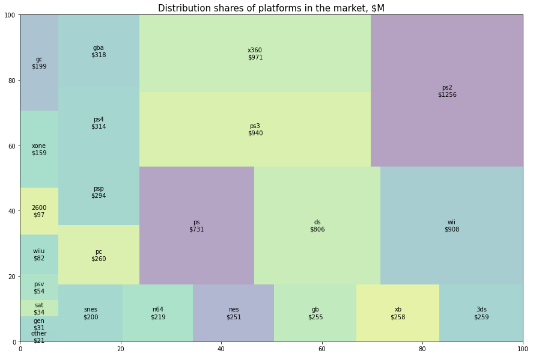

```python
# How are the platforms distributed in the market?
df_market = df[df['total_sales'] != 0]
total_sales = df_market.pivot_table(index='platform', values='total_sales',
                          aggfunc='sum').sort_values('total_sales').reset_index()
total_sales['platform'] = total_sales.apply(lambda x: str(x[0]) if int(x[1])>20 else 'other', axis=1)
total_sales = total_sales.pivot_table(index='platform', values='total_sales',
                          aggfunc='sum').sort_values('total_sales').reset_index()
sizes = total_sales['total_sales'].values.tolist()
labels = total_sales.apply(lambda x: str(x[0])+'\n'+'$'+str(round(x[1])), axis=1)

plt.figure(figsize=(15,10))
squarify.plot(sizes=sizes, label=labels, alpha=0.4)
plt.title('Distribution shares of platforms in the market, $M', fontdict={'size':15})
plt.show()
```

There are monster companies on the market with several generations of consoles that occupy the lion's share of the market: Sony (Play Station), Microsoft (X Box), Nintando (Wii, DS). Other smaller players have a small market.

```python
# Which platforms had more successful sales?

total_sales['sales_z'] = ((total_sales['total_sales'] - total_sales['total_sales'].mean())
                                / total_sales['total_sales'].std())
total_sales['colors'] = ['red' if x<0 else 'green' for x in total_sales['sales_z']]
```

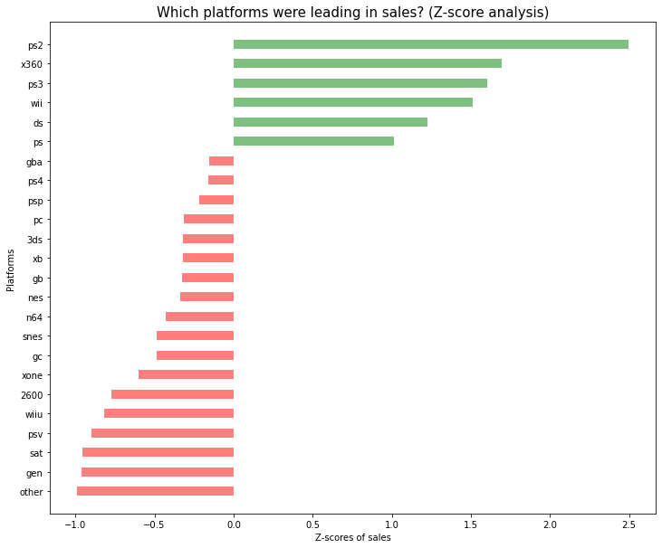

```python
plt.figure(figsize=(12,10))
plt.hlines(total_sales['platform'], xmin=0, xmax=total_sales['sales_z'],
           color=total_sales['colors'], alpha=0.5, linewidth=10)
plt.title('Which platforms were leading in sales? (Z-score analysis)', fontdict={'size':15})
plt.ylabel('Platforms')
plt.xlabel('Z-scores of sales')
plt.show()
```

Only 6 sites have a distribution of sales, which indicates really sales success.

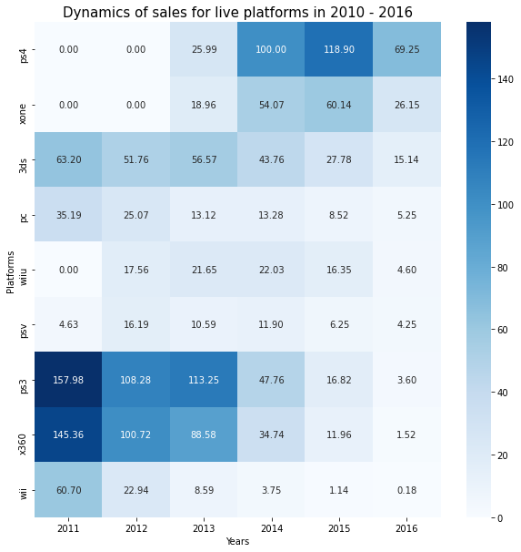

```python
# Which platforms were growing or shrinking in 2016?

df_grow = df[df['year_of_release'] > 2010].pivot_table(index='platform', columns='year_of_release',
                                                     values='total_sales', aggfunc='sum', fill_value=0)
df_grow = df_grow[df_grow[2016]>0].sort_values(2016, ascending=False)

plt.figure(figsize=(10,10))
sns.heatmap(df_grow, cmap='Blues', annot=True, fmt='.2f')
plt.title('Dynamics of sales for live platforms in 2010 - 2016', fontdict={'size':15})
plt.ylabel('Platforms')
plt.xlabel('Years')
plt.show()
```

How we can see all of the platforms have the shrinking tend for 2016. Most platforms had a peak of seles in 2011, close to the heyday of the industry. There were more significant results of sales for Xbox 360 and PS3 consoles. In 2016 PS4 and Xbox One feeling better than others because it passed the peak of development only in 2015. In fact, this is a continuation of the trends of previous generations of consoles: PS3 - PS4, X360 - XOne.

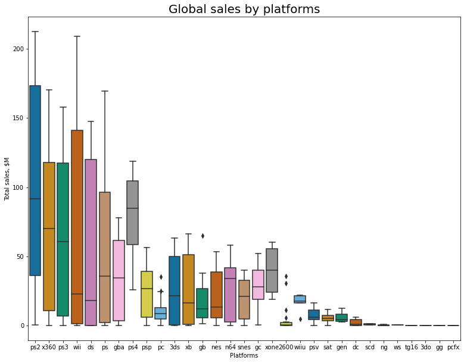

```python
# Build a box plot for the global sales of all games, broken down by platform.
ordered1 = df.pivot_table(index='platform', values='total_sales', aggfunc='sum')
ordered1 = ordered1.sort_values('total_sales', ascending=False).reset_index()

df_group = df.groupby(['platform', 'year_of_release'])['total_sales'].sum().reset_index()

plt.figure(figsize=(13, 10))
sns.boxplot(x='platform', y='total_sales', data=df_group, order=ordered1['platform'], palette='colorblind')
plt.title('Global sales by platforms', fontdict={'size':20})
plt.ylabel('Total sales, $M')
plt.xlabel('Platforms')
plt.show()
```

How we can see in the picture we can split of result for 3 parts. Platforms with huge sales (from left to the right: from PS2 to PS), platforms with medium sales (from GBA to XOne), and platforms with small sales (from 2600 to PC FX).  
Huge sales platforms confirm the result of Z-score analysis about the leading sales.  
The average values of all the platforms shift to the different sides of the center.  
There is no common rule. This shift can have different reasons such as the general rise or fall of the market, next-generation platform launch.

Several platforms had the powered start of sales. PS4, 3DS, Xbox One, WiiU started from good levels straight away. Several platforms had outliers sales for some years.

```
Interactions between reviews and sales
```

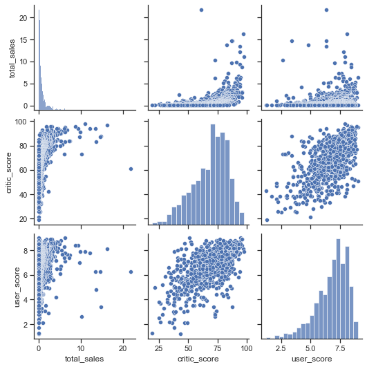

```python
# How user and professional reviews affect sales for Xbox 360?
df_x360 = (
           df[(df['platform'] == 'x360')
           & (df['critic_score'] != 0)
           & (df['user_score'] != 0)]
           )

df_x360 = df_x360[['total_sales', 'critic_score', 'user_score']]
sns.set(style="ticks")
print('Interactions between reviews and sales')
sns.pairplot(data=df_x360, height=2.5)
plt.show()
```

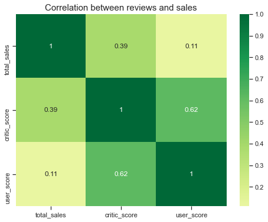

```python
plt.figure(figsize=(8,6))
sns.heatmap(df_x360.corr(), xticklabels=df_x360.corr().columns, yticklabels=df_x360.corr().columns,
            cmap='RdYlGn', center=0, annot=True)
plt.title('Correlation between reviews and sales', fontsize=15)
plt.show()
```

We can say that user reviews definitely have no impact on game sales. Critical reviews have some impact on sales, but not much. I think rather users trust self-experience and want to try new games they self.

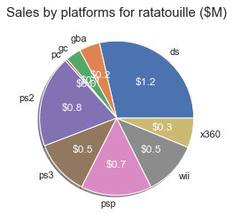

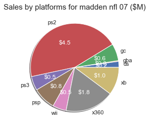

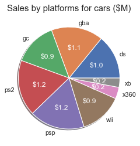

```python
# Let's compare the sales of the same games on other platforms.

df.pivot_table(index='name', values='platform', aggfunc='count').sort_values('platform', ascending=False).head(10)
# take some games for comparison sales by platforms
list_games = ['ratatouille', 'madden nfl 07', 'cars']
for n in list_games:
    df_game = df[df['name'] == n]
    pie_game = df_game.groupby('platform')['total_sales'].sum()
    p, tx, autotexts = plt.pie(pie_game, labels= pie_game.index, autopct='', shadow=True)
    for i, a in enumerate(autotexts):
        a.set_text("${:.1f}".format(pie_game[i]))
        a.set_color(color='white')
    plt.title("Sales by platforms for "+n+' ($M)', fontsize=15)
    plt.ylabel("")
    plt.show()
```

Some games more success for definite platforms, others are popular for all platforms. Also, there are unique cases, when the game has unbelievable sale only for one platform. For example 'Wii sports' was an absolute leader of sales among all games:

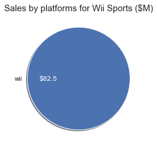

```python
df_game = df[df['name'] == 'wii sports']
pie_game = df_game.groupby('platform')['total_sales'].sum()
p, tx, autotexts = plt.pie(pie_game, labels= pie_game.index, autopct='', shadow=True)
for i, a in enumerate(autotexts):
    a.set_text("${:.1f}".format(pie_game[i]))
    a.set_color(color='white')
plt.title("Sales by platforms for Wii Sports ($M)", fontsize=15)
plt.show()
```

```python
# Study the general distribution of games by genres.

genre_sales = df.pivot_table(index='genre', values='total_sales',
                       aggfunc='sum').sort_values('total_sales', ascending=False).reset_index()
```

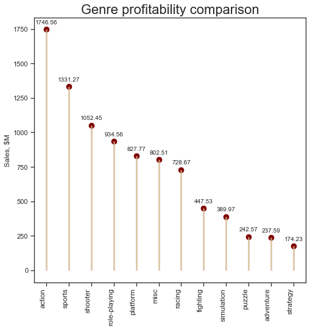

```python
fig, ax = plt.subplots(figsize=(8,8))
ax.vlines(x=genre_sales.genre, ymin=0, ymax=genre_sales.total_sales, color='tan', alpha=0.7, linewidth=3)
ax.scatter(x=genre_sales.genre, y=genre_sales.total_sales, s=75, color='maroon')
ax.set_title('Genre profitability comparison', fontdict={'size':22})
ax.set_ylabel('Sales, $M')
ax.set_xticks(genre_sales.genre)
ax.set_xticklabels(genre_sales.genre, rotation=90, fontdict={'horizontalalignment': 'right', 'size':12})
for row in genre_sales.itertuples():
    ax.text(row.genre, row.total_sales+40, s=round(row.total_sales, 2),
            fontdict={'horizontalalignment': 'center','size':10})
plt.show()
```

How we can see on the graph the most high-profitable genre is action (1,7B USD) and the most low-profitable is strategy (174,2M USD). The difference of sales about 10 times. These results are connected with the number of game sales.

```python
df.query('genre=="action" or genre=="strategy"').pivot_table(index='genre', values='total_sales',
                       aggfunc=['sum','count','mean','max']).reset_index()
```

|  | genre | sum total_sales | count total_sales | mean total_sales | max total_sales |
| --- | --- | --- | --- | --- | --- |
| 0 | action | 1746.56 | 3370 | 0.518267 | 21.05 |
| 1 | strategy | 174.23 | 683 | 0.255095 | 5.45 |

## 4. Creating a user profile for each region

For each region (NA, EU, JP), determine:

- The top five platforms. Describe variations in their market shares from region to region.
- The top five genres. Explain the difference.
- Do ESRB ratings affect sales in individual regions?

```python
#  Study the market shares for 5 top platforms by regions.

list_platforms = ordered1[ordered1.index < 5]['platform'].tolist()

df_top_platforms = df.query('platform in @list_platforms')
top_platforms = df_top_platforms.pivot_table(index = 'platform', values=['na_sales', 'eu_sales', 'jp_sales'],
                                             aggfunc='sum').sort_values('na_sales', ascending=False).reset_index()
```

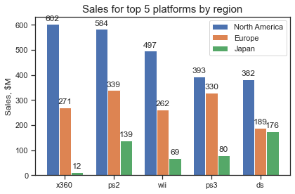

```python
labels = top_platforms['platform'].tolist()
na = top_platforms['na_sales'].tolist()
eu = top_platforms['eu_sales'].tolist()
jp = top_platforms['jp_sales'].tolist()
x = np.arange(len(labels))  # the label locations
width = 0.25  # the width of the bars

fig, ax = plt.subplots()
rects1 = ax.bar(x - width, na, width, label='North America')
rects2 = ax.bar(x, eu, width, label='Europe')
rects3 = ax.bar(x + width, jp, width, label='Japan')

ax.set_ylabel('Sales, $M')
ax.set_title('Sales for top 5 platforms by region', fontdict={'size':15})
ax.set_xticks(x)
ax.set_xticklabels(labels)
ax.legend()

def autolabel(rects):
    """Attach a text label above each bar in *rects*, displaying its height."""
    for rect in rects:
        height = rect.get_height()
        ax.annotate('{:.0f}'.format(height),
                    xy=(rect.get_x() + rect.get_width() / 2, height),
                    xytext=(0, 3),  # 3 points vertical offset
                    textcoords="offset points",
                    ha='center', va='bottom')


autolabel(rects1)
autolabel(rects2)
autolabel(rects3)

fig.tight_layout()

plt.show()
```

```python
list_genres = genre_sales[genre_sales.index < 5]['genre'].tolist()
df_top_genres = df.query('genre in @list_genres')
top_genres = df_top_genres.pivot_table(index = 'genre', values=['na_sales', 'eu_sales', 'jp_sales'],
                                             aggfunc='sum').sort_values('na_sales').reset_index()
```

North America is a leader of sales for all 5 top platforms. The most popular platform was Xbox 360. For other regions a situation was different. For Japan Xbox 360 turned out the least popular console, but Nintendo DS was the most popular. In Europe, the most popular was PS2, and the least was Nintendo DS. A preference of European gamers in common the same that for American gamers, but European more love products of Sony (PS2, PS3).

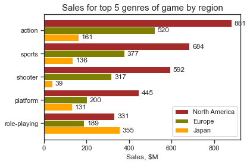

```python
#   Study the sales for 5 top genres by regions.

labels = top_genres['genre'].tolist()
na = top_genres['na_sales'].tolist()
eu = top_genres['eu_sales'].tolist()
jp = top_genres['jp_sales'].tolist()
x = np.arange(len(labels))
width = 0.30

fig, ax = plt.subplots()
rects1 = ax.barh(x + width, na, width, label='North America', color='brown')
rects2 = ax.barh(x, eu, width, label='Europe', color='olive')
rects3 = ax.barh(x - width, jp, width, label='Japan', color='orange')

ax.set_xlabel('Sales, $M')
ax.set_title('Sales for top 5 genres of game by region', fontdict={'size':15})
ax.set_yticks(x)
ax.set_yticklabels(labels)
ax.legend()

def autolabel(rects):
    for rect in rects:
        width = rect.get_width()
        ax.annotate('{:.0f}'.format(width),
                    xy=(rect.get_width(), rect.get_y() + rect.get_height() / 2),
                    xytext=(5, 0),
                    textcoords="offset points",
                    ha='left', va='center')

autolabel(rects1)
autolabel(rects2)
autolabel(rects3)

fig.tight_layout()

plt.show()
```

American end European gamers very love the action genre. Japanese gamers have other preferences. The most popular genre in Japan was role-playing.

```python
#  Study how ESRB rating affects sales.

# Make dataset for analysis of the distribution of ESRB rating by regions.
df_rate = pd.DataFrame(columns=['Name', 'Years', 'Rating', 'Region', 'Sales'])
for row in df.itertuples():

    if row.year_of_release < 2000:
        year = 'Before 2000'
    elif row.year_of_release <= 2010:
        year = '2000 - 2010'
    elif row.year_of_release > 2010:
        year = 'After 2010'

    if row.na_sales > 0:
        df_rate = df_rate.append({'Name': row.name,
                                  'Years': year,
                                  'Rating': row.rating,
                                  'Region': 'North America',
                                  'Sales': row.na_sales},
                                 ignore_index=True)

    if row.eu_sales > 0:
        df_rate = df_rate.append({'Name': row.name,
                                  'Years': year,
                                  'Rating': row.rating,
                                  'Region': 'Europe',
                                  'Sales': row.eu_sales},
                                 ignore_index=True)

    if row.jp_sales > 0:
        df_rate = df_rate.append({'Name': row.name,
                                  'Years': year,
                                  'Rating': row.rating,
                                  'Region': 'Japan',
                                  'Sales': row.jp_sales},
                                 ignore_index=True)


df_rate=df_rate.query('Sales < 20') # Drop some outliers
```

```
Sales of games by ESRB rating by region
```

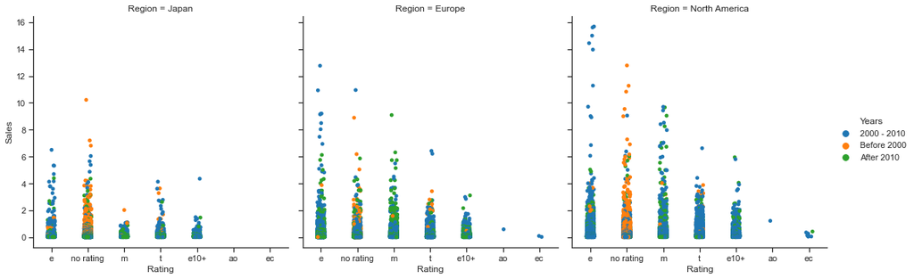

```python
print('Sales of games by ESRB rating by region')

sns.catplot(x="Rating", y="Sales",
            hue="Years",
            col="Region",
            data=df_rate,
            orient="v", height=5, aspect=1, palette="tab10"
           )
plt.show()
```

We can see on the graph that a large number of values 'No Rating' refer to the period before 2000. For North America 'Everyone' and 'Mature' ratings had the most higher sales among rated games. For Europe the same situation. For the Japanese market 'Mature' rating was less interesting.

This result for sales of games with different ESRB rating. However, it didn't give a full answer to the question of how ESRB rating affects sales. Let's look at how rating influent for sales for games one-year sales. For it let's compare average values of genre games:

```python
# Drop off values before 2000 and games with rare ratings
rate_pivot = (df_rate.query('Years != "Before 2000" & Rating != "ao" & Rating != "ec"')
             .pivot_table(index='Region', columns='Rating', values='Sales')
             .sort_values('m', ascending=False).reset_index())
```

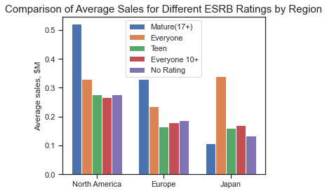

```python
labels = rate_pivot['Region'].tolist()
e = rate_pivot['e'].tolist()
e10 = rate_pivot['e10+'].tolist()
m = rate_pivot['m'].tolist()
t = rate_pivot['t'].tolist()
no_r = rate_pivot['no rating'].tolist()

x = np.arange(len(labels))  # the label locations
width = 0.15  # the width of the bars

fig, ax = plt.subplots()
rects1 = ax.bar(x - 2*width, m, width, label='Mature(17+)')
rects2 = ax.bar(x - width, e, width, label='Everyone')
rects3 = ax.bar(x, t, width, label='Teen')
rects4 = ax.bar(x + width, e10, width, label='Everyone 10+')
rects5 = ax.bar(x + 2*width, no_r, width, label='No Rating')

ax.set_ylabel('Average sales, $M')
ax.set_title('Comparison of Average Sales for Different ESRB Ratings by Region', fontdict={'size':15})
ax.set_xticks(x)
ax.set_xticklabels(labels)
ax.legend()

fig.tight_layout()
plt.show()
```

How we can see 'Mature' rating games were a more profitable product for North America and Europe. For Japanese market lead 'Everyone' rating games.

## 5. Testing the hypotheses

1. Let's check hypothesis.

Alpha = 0,05.  
Because this is the most common alpha value for analysis.

```python
df_user = df[df['user_score'] != 0]
sample_xbox = df_user.query('platform == "x360" or platform == "xone"')['user_score']
sample_pc = df_user.query('platform == "pc"')['user_score']

alpha = .05
results = st.ttest_ind(
        sample_xbox,
        sample_pc,
        )

print('p-value: ', results.pvalue)
if (results.pvalue < alpha):
        print('We reject the null hypothesis')
else:
        print("We can't reject the null hypothesis")
```

```
p-value:  4.30113816248073e-09
We reject the null hypothesis
```

Our hypothesis didn't confirm. The probability of crossing of values of distribution very small.  
I think there are different users for Xbox and PC. Users for PC more adults than for game consoles, because PC is not only a game platform but also a tool for work. A lot of adults are gaming on PC.

1. Let's check another hypothesis.

#### Null hypothesis: Average user ratings for the Action and Sports genres are the same.

Alternative hypothesis: Average user ratings for the Action and Sports genres are the different.

Also Alpha = 0,05.

```python
df_user = df[df['user_score'] != 0]

sample_action = df_user[(df_user['genre'] == 'action')]['user_score']
sample_sports = df_user[df_user['genre'] == 'sports']['user_score']

alpha = .05

results = st.ttest_ind(
        sample_action,
        sample_sports,
        )

print('p-value: ', results.pvalue)

if (results.pvalue < alpha):
        print('We reject the null hypothesis')
else:
        print("We can't reject the null hypothesis")
```

```
p-value:  0.10406951359049141
We can't reject the null hypothesis
```

The hypothesis about the coincidence of average user ratings for the Action and Sports genres are confirmed. The p-value tells us that although the average scores for the two genres are different, there is more than a 10% probability of randomly getting a crossing of average values of user's scores.

## 6. General conclusion and recommendations.

I have exacted research on the market of games for the period 1980 - 2016. The initial goal of the study is to find growth points and business development prospects for an online game store that sells games for different platforms around the world.

Most of the research results (for the period up to 2010) are unlikely to be useful for developing direct recommendations and making forecasts, but they give an idea of such concepts as the life cycle of platforms, the popularity of genres, and the impact of reviews on sales.

Since the beginning of the study period in 1980, the games industry has grown steadily until the pivotal year for the industry in 2008. 2008 - 2009 were the most successful years for the market. During these years, the maximum number of unique games was released, as well as the maximum number of their porting to platforms. After those years in general the market was only shrinking.

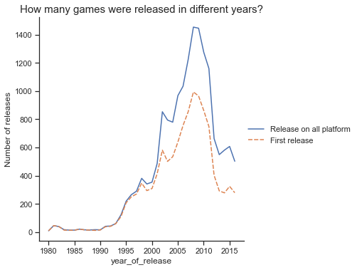

```python
sns.relplot(data=num_release_by_years, kind='line')
plt.title('How many games were released in different years?', fontdict={'size':15})
plt.ylabel('Number of releases')
plt.show()
```

In addition to the fracture in 2008, the chart also shows other small periods of market downturns in 1998, 2002, 2015. All these breaking points are associated with the general economic situation. In all of these years, there were recessions in the world economy.  
The gaming industry is highly dependent on investor money. During economic downturns, the flow of investment in the industry declines.  
As you know, in 2008 there was an economic crisis that hit many industries hard. As we can see from the graph, the games industry was unable to recover its previous growth and since then the market volume has been steadily declining.  
By 2016, only 9 gaming platforms remained alive, of which only 3 have a significant annual turnover.

The study of the reasons for such a fall in the market is not the subject of this study, however, it can be assumed that the downward trend in all gaming platforms is due to the emergence of new platforms for games such as smartphones and platforms for browser online games. And also as a result of the fact that selling games are no longer the main business goal for game developers. Games have become a platform for permanent earnings for game manufacturers from in-game currency, for the sale of various game items and additional gaming options. Many games have therefore become free.

Another problem for professional game sellers was the impossibility of entering the market for mobile applications. Google and Apple have essentially become monopolists in selling games on their platforms. It's a sad fact that market competition kills, but game sellers have to play by these rules.

Recommendations and forecasts for 2017 and the coming years:

- I recommend to continue selling games on the following platforms: PS4, Xbox One, Nintendo 3DS, PC.
- I propose to focus not only on the selling games but also on other goods from the world of games, such as gaming currency cards, game consoles, and other gaming equipment, souvenirs, clothing, and items with a gaming identity.
- The development of social media accounts on the basis of the existing brand, and attract a large number of subscribers can become new profit centers for an online game store.